# Titanic Survival Project

Chi Cheng

February 1, 2017

### **Overview**

##### This is my first Kaggle work. I’ve done around 30 iterations trying different manipulation techniques, combination of predictors as well as different modeling techniques (mostly around CART, Random Forest, GBM and SVM). To simply this result demonstration, I am going to show only the iteration which generated the highst score (**0.80861**) on the leaderboard. I sincerely welcome any suggestion that may help to improve the work.

### **Detailed Solution**

#### **1. Packages Loading**

```r
library(caret) # model training
library(ROCR) # model evaluation - ROC
library(data.table) # data table format for manipulation
library(ggplot2) # visualization
library(plyr) # data manipulation
library(dplyr) # data manipulation
library(kernlab) # SVM
```

#### **2. Data Loading**

##### Load in datasets, use “na.strings” to convert blank as missing

```r
training = read.csv("train.csv",na.strings=c("","NA"))
dim(training)
```

```
## [1] 891  12
```

```r
testing = read.csv("test.csv",na.strings=c("","NA"))
dim(testing)
```

```
## [1] 418  11
```

##### Impute a placeholder for the target variable “Survived” in testing dataset

```r
testing$Survived = NA
testing = testing[,c(1,12,2:11)] # Align the sequence of columns between the two datasets
```

##### Assign an indicator for TRN/TST/VAL

```r
set.seed(1)
ind = createDataPartition(training$Survived,p=0.6,list=F)
training_trn = training[ind,]
training_trn$SPLIT = "TRN"
training_tst = training[-ind,]
training_tst$SPLIT = "TST"
testing$SPLIT = "VAL"
```

##### Combine the two datasets for data cleansing and manipulation purpose

```r
all = rbind(training_trn,training_tst,testing)
table(all$SPLIT)
```

```
##
## TRN TST VAL
## 535 356 418
```

##### Convert the all dataset to data.table format for easy manipulation

```r
all = as.data.table(all)
```

#### **3. Data Cleansing and Manipulation**

##### Extract title from Name

```r
all$Title = gsub('(.*, )|(\\..*)', '', all$Name)
```

##### Categorize the rare title categories as “Rare_Title”

```r
rare_Title = c("Don","Rev","Dr","Mme","Major","Mlle","Col","Jonkheer","Ms",
               "Lady","Sir","Capt","the Countess","Dona")
all[all$Title %in% rare_Title,]$Title = "Rare_Title"
table(all$Title)
```

```
##
##     Master       Miss         Mr        Mrs Rare_Title
##         61        260        757        197         34
```

##### **Impute the missing values**

##### Create missing value summary table

```r
naSummary = function(data){
  na_summary = data.frame(num_na = colSums(is.na(data)))
  na_summary = data.frame(Variable = rownames(na_summary),na_summary,
                          na_ratio = na_summary$num_na/nrow(data))
}
na_summary = naSummary(all)
na_summary = na_summary[order(na_summary$num_na,decreasing = T),]
head(na_summary)
```

[output not shown]

##### “Age” has 263 missing values, impute the missing “Age” by median controlling Pclass and Sex

##### Create age summary table for different combination of Pclass and Sex

```r
age_summary = all[,.(Age = median(Age,na.rm=T)),by=c("Sex","Pclass")]
age_summary$Age_abs = round(age_summary$Age,0)
head(age_summary)
```

```
##       Sex Pclass  Age Age_abs
## 1:   male      3 25.0      25
## 2: female      1 36.0      36
## 3: female      2 28.0      28
## 4: female      3 22.0      22
## 5:   male      2 29.5      30
## 6:   male      1 42.0      42
```

##### Impute the missing age

###### *note that I’ve also tried random forest imputation however the score was not as high as the below imputation*

##### “Age” distribution before imputation

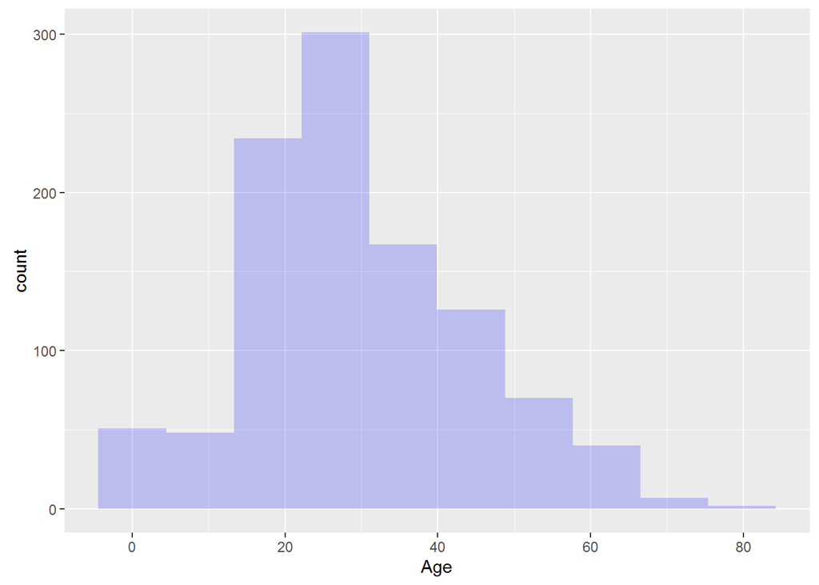

```r
ggplot(data=all,aes(x=Age)) + geom_histogram(bins=10, na.rm=T,fill="blue",alpha=0.2)
```

##### Impute the “Age”

```r
all$Age[all$Sex == "male" & all$Pclass == 1
        & is.na(all$Age)] = age_summary[age_summary$Sex == "male"
                                        & age_summary$Pclass == 1,Age_abs]

all$Age[all$Sex == "male" & all$Pclass == 2
        & is.na(all$Age)] = age_summary[age_summary$Sex == "male"
                                        & age_summary$Pclass == 2,Age_abs]

all$Age[all$Sex == "male" & all$Pclass == 3
        & is.na(all$Age)] = age_summary[age_summary$Sex == "male"
                                        & age_summary$Pclass == 3,Age_abs]

all$Age[all$Sex == "female" & all$Pclass == 1
        & is.na(all$Age)] = age_summary[age_summary$Sex == "female"
                                        & age_summary$Pclass == 1,Age_abs]

all$Age[all$Sex == "female" & all$Pclass == 2
        & is.na(all$Age)] = age_summary[age_summary$Sex == "female"
                                        & age_summary$Pclass == 2,Age_abs]

all$Age[all$Sex == "female" & all$Pclass == 3
        & is.na(all$Age)] = age_summary[age_summary$Sex == "female"
                                        & age_summary$Pclass == 3,Age_abs]
```

##### “Age” distribution after imputation

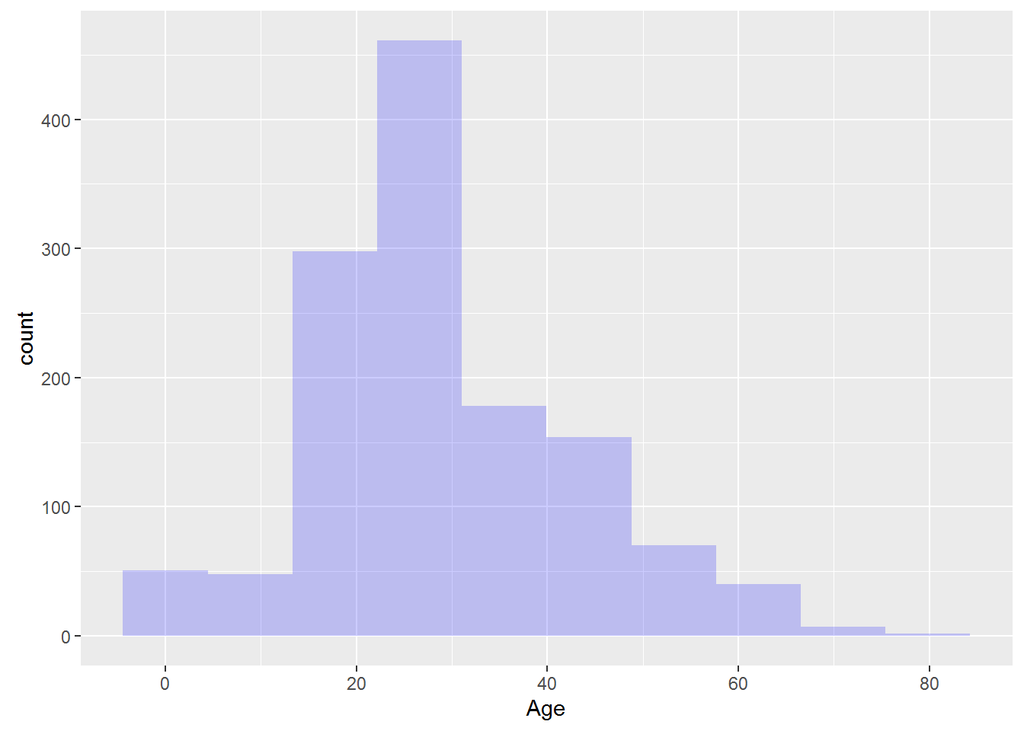

```r
ggplot(data=all,aes(x=Age)) + geom_histogram(bins=10, na.rm=T,fill="blue",alpha=0.2)
```

##### For “Cabin”, extract the first letter as high-level category, impute a new category to indicate missing value category

```r
all[is.na(all$Cabin)]$Cabin = 'Z'
all$cabin_num = substr(all$Cabin,1,1)
all$cabin_num = as.factor(all$cabin_num)
all[is.na(all$cabin_num),]$cabin_num = 'Z'
table(all$cabin_num)
```

```
##
##    A    B    C    D    E    F    G    T    Z
##   22   65   94   46   41   21    5    1 1014
```

##### “Embark” has 2 missing values, impute with mode controlling Pclass and Sex

```r
Mode <- function(x) {
  ux <- unique(x)
  ux[which.max(tabulate(match(x, ux)))]
}

all[is.na(all$Embarked),]
```

```
##    PassengerId Survived Pclass                                      Name
## 1:         830        1      1 Stone, Mrs. George Nelson (Martha Evelyn)
## 2:          62        1      1                       Icard, Miss. Amelie
##       Sex Age SibSp Parch Ticket Fare Cabin Embarked SPLIT Title cabin_num
## 1: female  62     0     0 113572   80   B28       NA   TRN   Mrs         B
## 2: female  38     0     0 113572   80   B28       NA   TST  Miss         B
```

```r
all[is.na(all$Embarked)]$Embarked = all[Sex=="female" & Pclass==1,.(Embarked = Mode(Embarked)),by=c("Sex","Pclass")]$Embarked
```

```r
all[is.na(all$Fare),]
```

```
##    PassengerId Survived Pclass               Name  Sex  Age SibSp Parch
## 1:        1044       NA      3 Storey, Mr. Thomas male 60.5     0     0
##    Ticket Fare Cabin Embarked SPLIT Title cabin_num
## 1:   3701   NA     Z        S   VAL    Mr         Z
```

```r
all$Fare[is.na(all$Fare)] = all[Sex=="male" & Pclass==3,.(Fare = mean(Fare,na.rm = T)),by=c("Sex","Pclass")]$Fare
```

##### Double check if there is still missing value

```r
colSums(is.na(all))
```

```
## PassengerId    Survived      Pclass        Name         Sex         Age
##           0         418           0           0           0           0
##       SibSp       Parch      Ticket        Fare       Cabin    Embarked
##           0           0           0           0           0           0
##       SPLIT       Title   cabin_num
##           0           0           0
```

##### Create synthetic variables - “family size”

```r
all$fam_size = all$SibSp + all$Parch + 1
```

##### Transform factor variables into numeric indicators

```r
dummies = dummyVars(Survived~.-Name-Ticket-Cabin-SPLIT,data=all)
all_dummy = predict(dummies,newdata=all)
all_dummy = as.data.frame(all_dummy)
```

##### merge back “Passenger Id” and “SPLIT”

```r
all_sub = subset(all,select=c(PassengerId,Survived,SPLIT))
allvars = merge(all_sub,all_dummy,by="PassengerId",all=T)
```

#### **4. Univariate Analysis**

##### Divide allvars dataset into TRNTST and VAL

```r
allvars_trn = allvars[allvars$SPLIT=="TRN"|allvars$SPLIT=="TST",]
allvars_val = allvars[allvars$SPLIT == "VAL",]
```

##### Generate correlation summary

```r
allvars_cor = cor(subset(allvars_trn,select=-c(PassengerId,SPLIT,Survived)),allvars_trn$Survived)
cor_summary = as.data.frame(as.table(allvars_cor))
colnames(cor_summary)[3] = "correlation"
cor_summary$Var2 = "Survived"
cor_summary$abs_cor = abs(cor_summary$correlation)
cor_summary = cor_summary[order(cor_summary$abs_cor,decreasing = T),]
head(cor_summary,nrow(cor_summary))
```

```
##               Var1     Var2  correlation     abs_cor
## 13         TitleMr Survived -0.549199185 0.549199185
## 2       Sex.female Survived  0.543351381 0.543351381
## 3         Sex.male Survived -0.543351381 0.543351381
## 14        TitleMrs Survived  0.339040251 0.339040251
## 1           Pclass Survived -0.338481036 0.338481036
## 12       TitleMiss Survived  0.327092549 0.327092549
## 24     cabin_num.Z Survived -0.316911523 0.316911523
## 7             Fare Survived  0.257306522 0.257306522
## 17     cabin_num.B Survived  0.175095034 0.175095034
## 8       Embarked.C Survived  0.174717534 0.174717534
## 10      Embarked.S Survived -0.155660273 0.155660273
## 19     cabin_num.D Survived  0.150715644 0.150715644
## 20     cabin_num.E Survived  0.145321443 0.145321443
## 18     cabin_num.C Survived  0.114652115 0.114652115
## 11     TitleMaster Survived  0.085220561 0.085220561
## 6            Parch Survived  0.081629407 0.081629407
## 4              Age Survived -0.058760070 0.058760070
## 21     cabin_num.F Survived  0.057934947 0.057934947
## 5            SibSp Survived -0.035322499 0.035322499
## 23     cabin_num.T Survived -0.026456469 0.026456469
## 16     cabin_num.A Survived  0.022286954 0.022286954
## 15 TitleRare_Title Survived  0.022030256 0.022030256
## 25        fam_size Survived  0.016638989 0.016638989
## 22     cabin_num.G Survived  0.016040183 0.016040183
## 9       Embarked.Q Survived  0.003650383 0.003650383
```

##### Use mosaicplot to explore predictors (Pclass as an example)

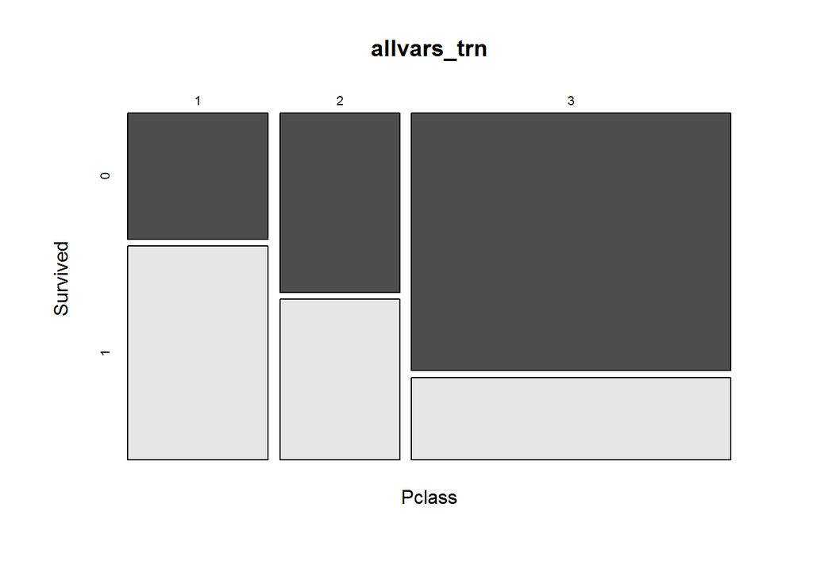

```r
mosaicplot(~ Pclass + Survived, data = allvars_trn, color = TRUE)
```

##### Final cleansing

```r
# Keep one sex indicator is enough
allvars_trn$Sex.male = NULL
allvars_val$Sex.male = NULL
# Combine the cabin_num to two group, Z, non-Z (all other categories show positive correlation and since the number of observations in each category is small, rather combine them together)
allvars_trn$cabin_cat = ifelse(allvars_trn$cabin_num.Z==1,0,1)
allvars_val$cabin_cat = ifelse(allvars_val$cabin_num.Z==1,0,1)
# Remove SPLIT
allvars_trn$SPLIT = NULL
allvars_val$SPLIT = NULL
# Format the target variable to be acceptable by R
allvars_trn$Survived = ifelse(allvars_trn$Survived==0,"Dead","Survived")
```

#### **5. Modeling**

##### Pre-processing

```r
# Further divide allvars_trn into two datasets for validation purpose
set.seed(12345)
trn_ind = createDataPartition(allvars_trn$Survived,p=0.6,list=F)
allvars_trn_trn = allvars_trn[trn_ind,] # build model on this dataset
allvars_trn_val = allvars_trn[-trn_ind,] # test model on this dataset until feeling comfortable
# Set up train control
control = trainControl(method="cv",number=5,classProbs = T)
```

##### SVM (Support Vector Machine)

##### First iteration: use the default tuning parameters

```r
system.time(mod_svmRadial <- train(as.factor(Survived)~.-PassengerId-cabin_num.B-cabin_num.A-cabin_num.D
                                   -cabin_num.E-cabin_num.T-cabin_num.G-cabin_num.F-TitleRare_Title
                                   -cabin_num.C-cabin_num.Z-Embarked.Q,
                                   data=allvars_trn_trn,method="svmRadial",
                                   trControl = control))
```

```
##    user  system elapsed
##    2.35    0.05    2.47
```

```r
mod_svmRadial
```

```
## Support Vector Machines with Radial Basis Function Kernel
##
## 536 samples
##  26 predictor
##   2 classes: 'Dead', 'Survived'
##
## No pre-processing
## Resampling: Cross-Validated (5 fold)
## Summary of sample sizes: 428, 429, 429, 429, 429
## Resampling results across tuning parameters:
##
##   C     Accuracy   Kappa
##   0.25  0.8320353  0.6415315
##   0.50  0.8264278  0.6289648
##   1.00  0.8413638  0.6544465
##
## Tuning parameter 'sigma' was held constant at a value of 0.1746595
## Accuracy was used to select the optimal model using  the largest value.
## The final values used for the model were sigma = 0.1746595 and C = 1.
```

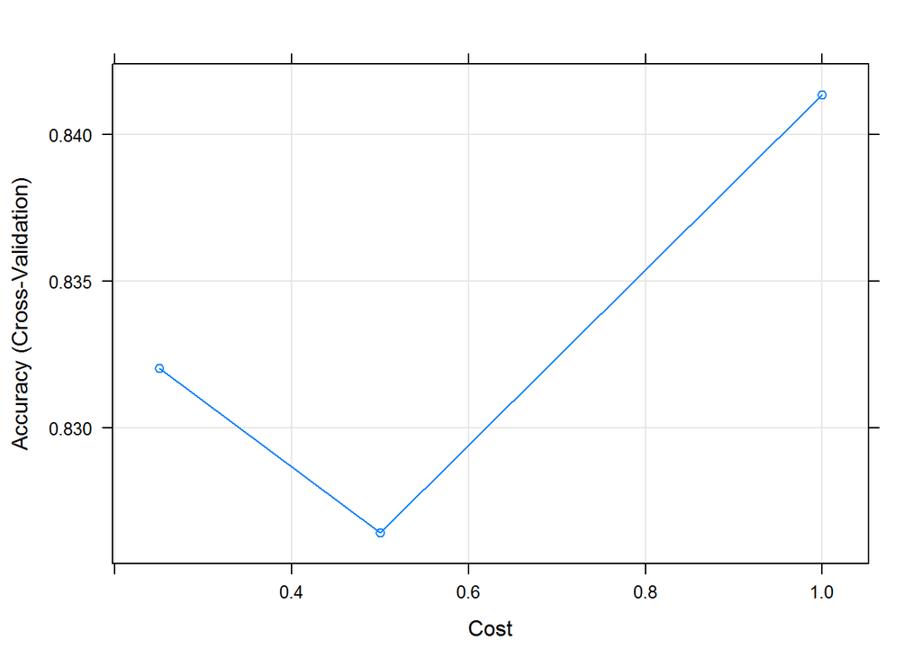

```r
plot(mod_svmRadial)
```

##### Second iteration: manually tune the parameters and compare performance

```r
svmRadialGrid = expand.grid(C=c(0.5,0.75,0.9,1,1.25),
                            sigma=c(0.01,0.02,0.03,0.04,0.05,0.1,0.12,0.15,0.2))
set.seed(123456)
system.time(mod_svmRadial <- train(as.factor(Survived)~.-PassengerId-cabin_num.B-cabin_num.A-cabin_num.D
                                   -cabin_num.E-cabin_num.T-cabin_num.G-cabin_num.F-TitleRare_Title
                                   -cabin_num.C-Embarked.Q-cabin_num.Z,
                                   data=allvars_trn_trn,method="svmRadial",
                                   trControl = control,tuneGrid=svmRadialGrid))
```

```
##    user  system elapsed
##   22.15    0.03   22.72
```

```r
mod_svmRadial
```

```
## Support Vector Machines with Radial Basis Function Kernel
##
## 536 samples
##  26 predictor
##   2 classes: 'Dead', 'Survived'
##
## No pre-processing
## Resampling: Cross-Validated (5 fold)
## Summary of sample sizes: 428, 429, 429, 429, 429
## Resampling results across tuning parameters:
##
##   C     sigma  Accuracy   Kappa
##   0.50  0.01   0.8208204  0.6142546
##   0.50  0.02   0.8264105  0.6260039
##   0.50  0.03   0.8375909  0.6512266
##   0.50  0.04   0.8413119  0.6593820
##   0.50  0.05   0.8450502  0.6673880
##   0.50  0.10   0.8431810  0.6637250
##   0.50  0.12   0.8487885  0.6759361
##   0.50  0.15   0.8487712  0.6769844
##   0.50  0.20   0.8413292  0.6619361
##   0.75  0.01   0.8208204  0.6142546
##   0.75  0.02   0.8375909  0.6512266
##   0.75  0.03   0.8431810  0.6637250
##   0.75  0.04   0.8450502  0.6673880
##   0.75  0.05   0.8469193  0.6710271
##   0.75  0.10   0.8525095  0.6843208
##   0.75  0.12   0.8525095  0.6836498
##   0.75  0.15   0.8469367  0.6714984
##   0.75  0.20   0.8394600  0.6554333
##   0.90  0.01   0.8189512  0.6098297
##   0.90  0.02   0.8394600  0.6556102
##   0.90  0.03   0.8450502  0.6673880
##   0.90  0.04   0.8450502  0.6673880
##   0.90  0.05   0.8469193  0.6710271
##   0.90  0.10   0.8543787  0.6880022
##   0.90  0.12   0.8506750  0.6796073
##   0.90  0.15   0.8450675  0.6667946
##   0.90  0.20   0.8375909  0.6483934
##   1.00  0.01   0.8189512  0.6098297
##   1.00  0.02   0.8413292  0.6599532
##   1.00  0.03   0.8450502  0.6673880
##   1.00  0.04   0.8469193  0.6710271
##   1.00  0.05   0.8469193  0.6710271
##   1.00  0.10   0.8525268  0.6825370
##   1.00  0.12   0.8544133  0.6862533
##   1.00  0.15   0.8394600  0.6524445
##   1.00  0.20   0.8413292  0.6557883
##   1.25  0.01   0.8245414  0.6228804
##   1.25  0.02   0.8450502  0.6673880
##   1.25  0.03   0.8450502  0.6673880
##   1.25  0.04   0.8469193  0.6710271
##   1.25  0.05   0.8469193  0.6710271
##   1.25  0.10   0.8506750  0.6771831
##   1.25  0.12   0.8450675  0.6647236
##   1.25  0.15   0.8431983  0.6587622
##   1.25  0.20   0.8431983  0.6589357
##
## Accuracy was used to select the optimal model using  the largest value.
## The final values used for the model were sigma = 0.12 and C = 1.
```

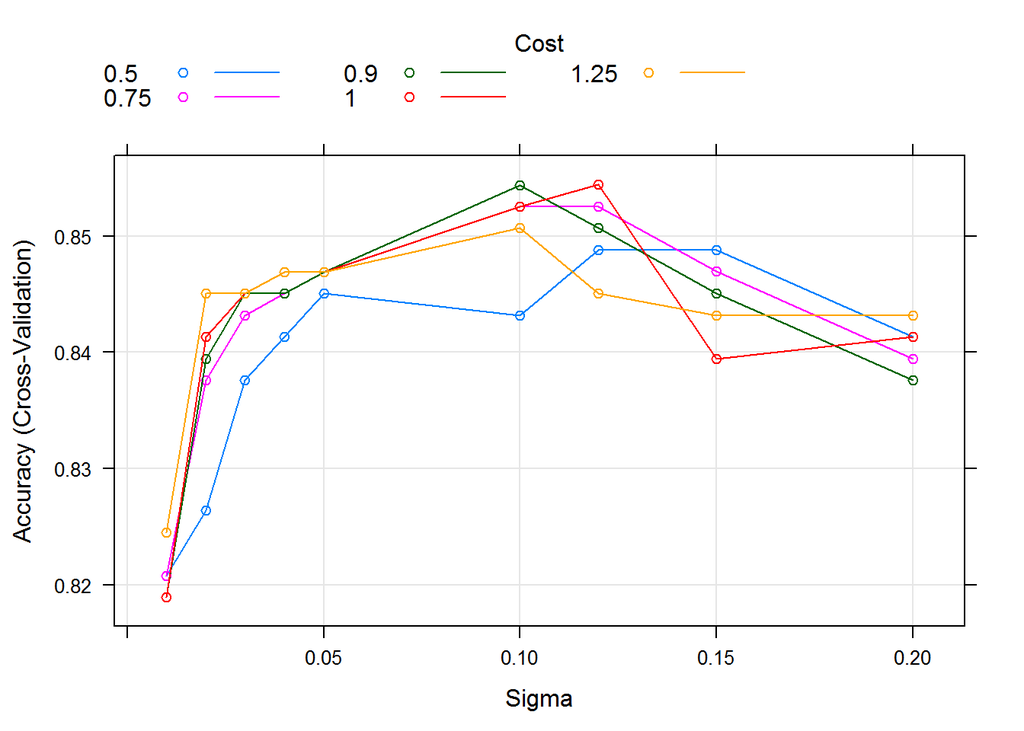

```r
plot(mod_svmRadial)
```

##### The model looks robust when sigma is between 0.10 to 0.15 and Cost is 0.75

##### Third iteration: choose a relatively robust model for prediction

```r
svmRadialGrid = expand.grid(C=0.75,
                            sigma=0.15)
set.seed(123456)
system.time(mod_svmRadial <- train(as.factor(Survived)~.-PassengerId-cabin_num.B-cabin_num.A-cabin_num.D
                                   -cabin_num.E-cabin_num.T-cabin_num.G-cabin_num.F-TitleRare_Title
                                   -cabin_num.C-Embarked.Q-cabin_num.Z,
                                   data=allvars_trn_trn,method="svmRadial",
                                   trControl = control,tuneGrid=svmRadialGrid))
```

```
##    user  system elapsed
##    0.93    0.02    0.96
```

```r
mod_svmRadial
```

```
## Support Vector Machines with Radial Basis Function Kernel
##
## 536 samples
##  26 predictor
##   2 classes: 'Dead', 'Survived'
##
## No pre-processing
## Resampling: Cross-Validated (5 fold)
## Summary of sample sizes: 428, 429, 429, 429, 429
## Resampling results:
##
##   Accuracy   Kappa
##   0.8488058  0.6759651
##
## Tuning parameter 'sigma' was held constant at a value of 0.15
##
## Tuning parameter 'C' was held constant at a value of 0.75
##
```

##### Predict on the allvars_trn_val dataset and test the performance

```r
svmRadial_pred = predict(mod_svmRadial,newdata=allvars_trn_val,type="raw")
confusionMatrix(svmRadial_pred,allvars_trn_val$Survived)
```

```
## Confusion Matrix and Statistics
##
##           Reference
## Prediction Dead Survived
##   Dead      192       40
##   Survived   27       96
##
##                Accuracy : 0.8113
##                  95% CI : (0.7666, 0.8506)
##     No Information Rate : 0.6169
##     P-Value [Acc > NIR] : 1.888e-15
##
##                   Kappa : 0.5933
##  Mcnemar's Test P-Value : 0.1426
##
##             Sensitivity : 0.8767
##             Specificity : 0.7059
##          Pos Pred Value : 0.8276
##          Neg Pred Value : 0.7805
##              Prevalence : 0.6169
##          Detection Rate : 0.5408
##    Detection Prevalence : 0.6535
##       Balanced Accuracy : 0.7913
##
##        'Positive' Class : Dead
##
```

##### Build model using allvars_trn and predict on allvars_val

```r
svmRadialGrid_final = expand.grid(C=0.75,
                                  sigma=0.15)
set.seed(123456)
system.time(mod_svmRadial <- train(as.factor(Survived)~.-PassengerId-cabin_num.B-cabin_num.A-cabin_num.D
                                   -cabin_num.E-cabin_num.T-cabin_num.G-cabin_num.F-TitleRare_Title
                                   -cabin_num.C-Embarked.Q-cabin_num.Z,
                                   data=allvars_trn,method="svmRadial",
                                   trControl = control,tuneGrid=svmRadialGrid_final))
```

```
##    user  system elapsed
##    1.60    0.02    1.61
```

```r
mod_svmRadial
```

```
## Support Vector Machines with Radial Basis Function Kernel
##
## 891 samples
##  26 predictor
##   2 classes: 'Dead', 'Survived'
##
## No pre-processing
## Resampling: Cross-Validated (5 fold)
## Summary of sample sizes: 713, 712, 714, 713, 712
## Resampling results:
##
##   Accuracy   Kappa
##   0.8350619  0.6435961
##
## Tuning parameter 'sigma' was held constant at a value of 0.15
##
## Tuning parameter 'C' was held constant at a value of 0.75
##
```

```r
svmRadial_pred_final = predict(mod_svmRadial,newdata=allvars_val,type="raw")
svmRadial_pred_submit = data.frame(PassengerId = allvars_val$PassengerId,Survived = svmRadial_pred_final)
svmRadial_pred_submit = svmRadial_pred_submit[order(svmRadial_pred_submit$PassengerId),]
svmRadial_pred_submit$Survived = ifelse(svmRadial_pred_submit$Survived=="Dead",0,1)
prop.table(table(svmRadial_pred_submit$Survived))
```

```
##
##         0         1
## 0.6291866 0.3708134
```

##### Save the result for submission

```r
write.csv(svmRadial_pred_submit,"pred_svmRadial.csv",row.names = F)
```